# Social_Media_Dataset

2024-03-29

```r
library(psych)
library(readr)
library(FactoMineR)
library(ggfortify)
```

```r
library(corrplot)
library(devtools)
dataset<- read.csv("C:/Users/mumba/Documents/Social_Media__Dataset.csv")
dataset <- dataset[-1]
str(dataset)
```

```
## 'data.frame':    21 obs. of  11 variables:
##  $ Instagram                 : num  3.5 7.73 3.77 5.38 12 2.33 5.37 7 8.65 0.17 ...
##  $ LinkedIn                  : num  4 5.2 7 5.32 0.58 7 4 4 10 0 ...
##  $ SnapChat                  : num  1 3.68 0.53 1.3 0 0.47 0 3 3.83 0 ...
##  $ Twitter                   : num  5 0 0 0 0.67 0 0 0 0 0 ...
##  $ Whatsapp.Wechat           : num  1 4.18 9.83 5.3 3 12 6 10 6.15 1 ...
##  $ youtube                   : num  2.5 4.25 1.85 2 3.5 7 3 2 4 3 ...
##  $ OTT                       : num  14.5 0 2 2 2 3 0 3 3 0 ...
##  $ Reddit                    : num  2.5 0 0 0 1 0 0 0 0 0 ...
##  $ Mood.Productivity         : int  1 1 1 1 1 1 1 1 1 0 ...
##  $ Tired.waking.up.in.morning: int  0 0 0 0 1 0 1 1 0 0 ...
##  $ Trouble.falling.asleep    : int  0 1 0 0 1 0 0 1 0 0 ...
```

```r
#data$OTT <- data$OTT..Netflix..Hulu..Prime.video..
summary(dataset)
```

```
##    Instagram         LinkedIn         SnapChat         Twitter
##  Min.   : 0.170   Min.   : 0.000   Min.   : 0.000   Min.   :0.0000
##  1st Qu.: 3.770   1st Qu.: 1.920   1st Qu.: 0.000   1st Qu.:0.0000
##  Median : 5.380   Median : 3.920   Median : 0.530   Median :0.0000
##  Mean   : 5.923   Mean   : 3.624   Mean   : 1.974   Mean   :0.5805
##  3rd Qu.: 7.000   3rd Qu.: 5.000   3rd Qu.: 1.870   3rd Qu.:0.2700
##  Max.   :15.020   Max.   :10.000   Max.   :14.870   Max.   :5.0000
##  Whatsapp.Wechat    youtube           OTT             Reddit
##  Min.   : 1.00   Min.   :0.000   Min.   : 0.000   Min.   :0.0000
##  1st Qu.: 3.67   1st Qu.:2.000   1st Qu.: 0.000   1st Qu.:0.0000
##  Median : 6.00   Median :3.000   Median : 1.680   Median :0.0000
##  Mean   : 6.43   Mean   :2.972   Mean   : 2.361   Mean   :0.5243
##  3rd Qu.: 8.92   3rd Qu.:4.000   3rd Qu.: 2.470   3rd Qu.:0.0000
##  Max.   :15.35   Max.   :7.000   Max.   :14.500   Max.   :7.0000
##  Mood.Productivity Tired.waking.up.in.morning Trouble.falling.asleep
##  Min.   :0.0000    Min.   :0.0000             Min.   :0.0000
##  1st Qu.:1.0000    1st Qu.:0.0000             1st Qu.:0.0000
##  Median :1.0000    Median :0.0000             Median :0.0000
##  Mean   :0.9524    Mean   :0.3333             Mean   :0.3333
##  3rd Qu.:1.0000    3rd Qu.:1.0000             3rd Qu.:1.0000
##  Max.   :1.0000    Max.   :1.0000             Max.   :1.0000
```

```r
stddataset <- scale(dataset)
stddataset
```

```
##         Instagram    LinkedIn    SnapChat     Twitter Whatsapp.Wechat
##  [1,] -0.68872811  0.15177439 -0.28112118  3.42449093     -1.34811606
##  [2,]  0.51370346  0.63652908  0.49216817 -0.44978498     -0.55854239
##  [3,] -0.61197716  1.36366111 -0.41673536 -0.44978498      0.84431651
##  [4,] -0.15431408  0.68500454 -0.19455894 -0.44978498     -0.28045354
##  [5,]  1.72750553 -1.22977648 -0.56966199  0.06936799     -0.85152885
##  [6,] -1.02131557  1.36366111 -0.43404781 -0.44978498      1.38311364
##  [7,] -0.15715671  0.15177439 -0.56966199 -0.44978498     -0.10664802
##  [8,]  0.30619162  0.15177439  0.29596043 -0.44978498      0.88652642
##  [9,]  0.77522521  2.57554784  0.53544929 -0.44978498     -0.06940398
## [10,] -1.63532317 -1.46407458 -0.56966199 -0.44978498     -1.34811606
## [11,] -0.38172431 -0.60363501 -0.44847485  1.42536456     -1.34811606
## [12,] -0.73705278 -0.45416898 -0.47444352  1.74305518     -0.68517213
## [13,] -0.17705510 -0.85005197  3.72093979 -0.44978498     -0.59826936
## [14,]  0.02192884 -0.25218786 -0.28112118  0.32507020     -0.74724553
## [15,] -0.36182591  0.05078382 -0.15993405 -0.44978498      0.01749879
## [16,]  0.30619162  0.55573663 -0.44847485 -0.44978498     -0.35494163
## [17,]  1.10212741 -1.14090479 -0.56966199 -0.24057409      1.71831001
## [18,]  0.24933907 -0.68846708 -0.03009068 -0.44978498      0.12923091
## [19,] -0.07187787  0.11945741 -0.56966199 -0.44978498      0.61836932
## [20,]  2.58597913  0.13157627  1.54245671 -0.44978498      2.21489723
## [21,] -1.58984113 -1.25401422 -0.56966199 -0.44978498      0.48429077
##           youtube         OTT      Reddit Mood.Productivity
##  [1,] -0.27184769  3.43816306  1.24055634         0.2182179
##  [2,]  0.73524935 -0.66869655 -0.32920042         0.2182179
##  [3,] -0.64591231 -0.10223316 -0.32920042         0.2182179
##  [4,] -0.55958970 -0.10223316 -0.32920042         0.2182179
##  [5,]  0.30363633 -0.10223316  0.29870228         0.2182179
##  [6,]  2.31783041  0.18099854 -0.32920042         0.2182179
##  [7,]  0.01589432 -0.66869655 -0.32920042         0.2182179
##  [8,] -0.55958970  0.18099854 -0.32920042         0.2182179
##  [9,]  0.59137834  0.18099854 -0.32920042         0.2182179
## [10,]  0.01589432 -0.66869655 -0.32920042        -4.3643578
## [11,] -1.13507372 -0.66869655 -0.32920042         0.2182179
## [12,] -0.27184769 -0.24384900 -0.32920042         0.2182179
## [13,] -1.39979638 -0.52424838 -0.32292139         0.2182179
## [14,] -0.27184769 -0.38546485 -0.32920042         0.2182179
## [15,]  0.09070724 -0.12489169  4.06611849         0.2182179
## [16,]  1.16686237 -0.38546485 -0.01524907         0.2182179
## [17,]  0.32090085 -0.19286730 -0.32920042         0.2182179
```

[output cut: 37 more lines]

```
##     Trouble.falling.asleep
##                  0.3333333
## attr(,"scaled:scale")
##                  Instagram                   LinkedIn
##                  3.5178717                  2.4754789
##                   SnapChat                    Twitter
##                  3.4657143                  1.2905637
##            Whatsapp.Wechat                    youtube
##                  4.0274899                  1.7376677
##                        OTT                     Reddit
##                  3.5306783                  1.5926034
##          Mood.Productivity Tired.waking.up.in.morning
##                  0.2182179                  0.4830459
##     Trouble.falling.asleep
##                  0.4830459
```

```r
datasetcov <- cov(dataset)
datasetcov
```

```
##                             Instagram    LinkedIn    SnapChat     Twitter
## Instagram                  12.3754214  0.84329214  3.53201714 -0.87530643
## LinkedIn                    0.8432921  6.12799571  0.21702571 -0.41729214
## SnapChat                    3.5320171  0.21702571 12.01117571 -0.80581214
## Twitter                    -0.8753064 -0.41729214 -0.80581214  1.66555476
## Whatsapp.Wechat             5.3534364  2.28309214  1.13128714 -2.57676476
## youtube                     2.0185829  1.94499429 -0.96223071 -0.42201119
## OTT                         3.3210371  1.62097571  1.61094571  2.53792952
## Reddit                     -0.4178829 -0.02790929 -0.44690929  0.33894786
## Mood.Productivity           0.2876429  0.18121429  0.09871429  0.02902381
## Tired.waking.up.in.morning  0.1170000 -0.39150000  0.31700000 -0.16966667
## Trouble.falling.asleep      0.8585000 -0.14950000  0.79450000 -0.04866667
##                            Whatsapp.Wechat      youtube           OTT
## Instagram                       5.35343643  2.018582857  3.3210371429
## LinkedIn                        2.28309214  1.944994286  1.6209757143
## SnapChat                        1.13128714 -0.962230714  1.6109457143
## Twitter                        -2.57676476 -0.422011190  2.5379295238
## Whatsapp.Wechat                16.22067476  2.602171190  1.8991954762
## youtube                         2.60217119  3.019489048  0.9860376190
## OTT                             1.89919548  0.986037619 12.4656890476
## Reddit                         -0.86244286  0.071974286  1.3100507143
## Mood.Productivity               0.27147619 -0.001380952  0.1180476190
## Tired.waking.up.in.morning     -0.08283333 -0.298333333 -0.3773333333
## Trouble.falling.asleep         -0.12283333  0.032666667 -0.0008333333
##                                 Reddit Mood.Productivity
## Instagram                  -0.41788286       0.287642857
## LinkedIn                   -0.02790929       0.181214286
## SnapChat                   -0.44690929       0.098714286
## Twitter                     0.33894786       0.029023810
## Whatsapp.Wechat            -0.86244286       0.271476190
## youtube                     0.07197429      -0.001380952
## OTT                         1.31005071       0.118047619
## Reddit                      2.53638571       0.026214286
## Mood.Productivity           0.02621429       0.047619048
## Tired.waking.up.in.morning -0.10800000       0.016666667
## Trouble.falling.asleep     -0.10800000       0.016666667
##                            Tired.waking.up.in.morning Trouble.falling.asleep
## Instagram                                  0.11700000           0.8585000000
## LinkedIn                                  -0.39150000          -0.1495000000
## SnapChat                                   0.31700000           0.7945000000
## Twitter                                   -0.16966667          -0.0486666667
## Whatsapp.Wechat                           -0.08283333          -0.1228333333
## youtube                                   -0.29833333           0.0326666667
## OTT                                       -0.37733333          -0.0008333333
## Reddit                                    -0.10800000          -0.1080000000
## Mood.Productivity                          0.01666667           0.0166666667
## Tired.waking.up.in.morning                 0.23333333           0.0833333333
## Trouble.falling.asleep                     0.08333333           0.2333333333
```

```r
# Formatting
datasetcov_rounded <- round(datasetcov, digits = 2)
datasetcov_df <- as.data.frame(datasetcov_rounded)
datasetcov_df
```

```
##                            Instagram LinkedIn SnapChat Twitter Whatsapp.Wechat
## Instagram                      12.38     0.84     3.53   -0.88            5.35
## LinkedIn                        0.84     6.13     0.22   -0.42            2.28
## SnapChat                        3.53     0.22    12.01   -0.81            1.13
## Twitter                        -0.88    -0.42    -0.81    1.67           -2.58
## Whatsapp.Wechat                 5.35     2.28     1.13   -2.58           16.22
## youtube                         2.02     1.94    -0.96   -0.42            2.60
## OTT                             3.32     1.62     1.61    2.54            1.90
## Reddit                         -0.42    -0.03    -0.45    0.34           -0.86
## Mood.Productivity               0.29     0.18     0.10    0.03            0.27
## Tired.waking.up.in.morning      0.12    -0.39     0.32   -0.17           -0.08
## Trouble.falling.asleep          0.86    -0.15     0.79   -0.05           -0.12
##                            youtube   OTT Reddit Mood.Productivity
## Instagram                     2.02  3.32  -0.42              0.29
## LinkedIn                      1.94  1.62  -0.03              0.18
## SnapChat                     -0.96  1.61  -0.45              0.10
## Twitter                      -0.42  2.54   0.34              0.03
## Whatsapp.Wechat               2.60  1.90  -0.86              0.27
## youtube                       3.02  0.99   0.07              0.00
## OTT                           0.99 12.47   1.31              0.12
## Reddit                        0.07  1.31   2.54              0.03
## Mood.Productivity             0.00  0.12   0.03              0.05
## Tired.waking.up.in.morning   -0.30 -0.38  -0.11              0.02
## Trouble.falling.asleep        0.03  0.00  -0.11              0.02
##                            Tired.waking.up.in.morning Trouble.falling.asleep
## Instagram                                        0.12                   0.86
## LinkedIn                                        -0.39                  -0.15
## SnapChat                                         0.32                   0.79
## Twitter                                         -0.17                  -0.05
## Whatsapp.Wechat                                 -0.08                  -0.12
## youtube                                         -0.30                   0.03
## OTT                                             -0.38                   0.00
## Reddit                                          -0.11                  -0.11
## Mood.Productivity                                0.02                   0.02
## Tired.waking.up.in.morning                       0.23                   0.08
## Trouble.falling.asleep                           0.08                   0.23
```

Positive values indicate that variables tend to increase or decrease together, while negative values suggest an inverse relationship. For example, Instagram and Whatsapp.WeChat have a high covariance, indicating they tend to increase or decrease together. A covariance of 0 suggests no linear relationship between variables.

```r
datasetmean <-  colMeans(dataset)
datasetmean
```

```
##                  Instagram                   LinkedIn
##                  5.9228571                  3.6242857
##                   SnapChat                    Twitter
##                  1.9742857                  0.5804762
##            Whatsapp.Wechat                    youtube
##                  6.4295238                  2.9723810
##                        OTT                     Reddit
##                  2.3609524                  0.5242857
##          Mood.Productivity Tired.waking.up.in.morning
##                  0.9523810                  0.3333333
##     Trouble.falling.asleep
##                  0.3333333
```

These mean values for each variable in the dataset indicate typical usage or experience

```r
dataset_MD <- mahalanobis(dataset, datasetmean, datasetcov)
dataset_MD
```

```
##  [1] 17.025436  6.841955  7.252330  7.620493  9.992494 12.121246  5.495559
##  [8]  8.633741 12.696170 19.047619 11.234332  9.192783 17.517866  4.627127
## [15] 18.706054  7.807098 10.078091  5.863882  4.404183 13.813103 10.028439
```

```r
#My usage vs class
dataset_MD[10]
```

```
## [1] 19.04762
```

The output [10] 19.04762 indicates the Mahalanobis distance for the my usage with the class.

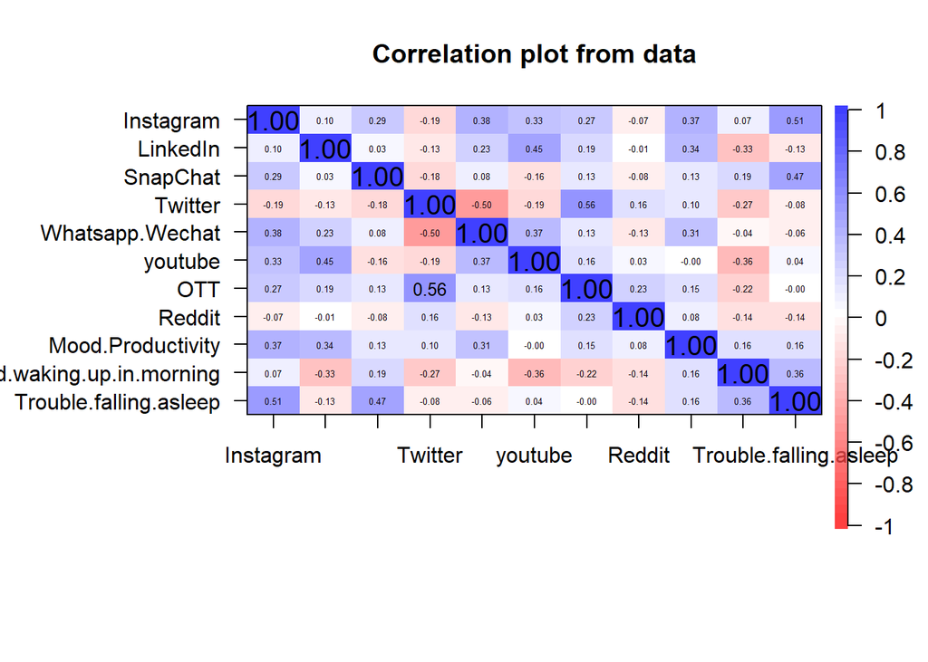

```r
# Lets plot correlation between columns
cor.plot(dataset)
```

Insights: Users who spend more time on Instagram tend to also use Snapchat and WhatsApp/WeChat extensively. People who have difficulty waking up feeling tired in the morning also tend to experience trouble falling asleep. Those who struggle to fall asleep are more likely to spend significant time on Instagram and Snapchat. Users who report feeling tired upon waking up in the morning have an opposite correlation with LinkedIn and YouTube, implying that those who use LinkedIn and YouTube less tend to feel more tired in the morning.

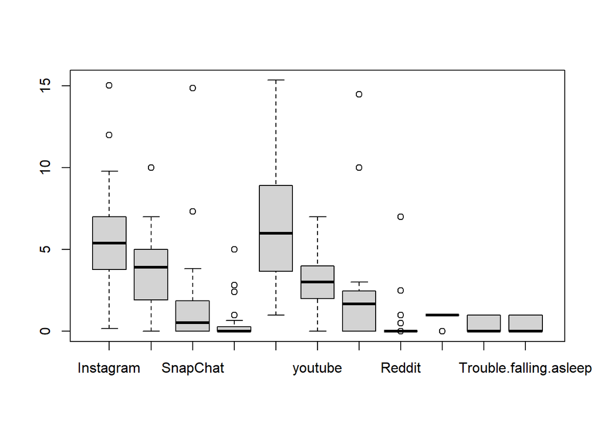

```r
#Lets identify outliers in our dataset
boxplot(dataset)
```

We could see there are many outlier. ## Principal Component Analysis

```r
cor(dataset)
```

```
##                              Instagram     LinkedIn    SnapChat     Twitter
## Instagram                   1.00000000  0.096836443  0.28970103 -0.19279717
## LinkedIn                    0.09683644  1.000000000  0.02529643 -0.13061755
## SnapChat                    0.28970103  0.025296428  1.00000000 -0.18016133
## Twitter                    -0.19279717 -0.130617547 -0.18016133  1.00000000
## Whatsapp.Wechat             0.37784893  0.228996980  0.08104862 -0.49574787
## youtube                     0.33021732  0.452160243 -0.15977901 -0.18818187
## OTT                         0.26738411  0.185463793  0.13165277  0.55698302
## Reddit                     -0.07458765 -0.007079162 -0.08096904  0.16490954
## Mood.Productivity           0.37469961  0.335461630  0.13052596  0.10305869
## Tired.waking.up.in.morning  0.06885214 -0.327404125  0.18935558 -0.27216275
## Trouble.falling.asleep      0.50520997 -0.125024053  0.47458362 -0.07806633
##                            Whatsapp.Wechat      youtube           OTT
## Instagram                       0.37784893  0.330217323  0.2673841069
## LinkedIn                        0.22899698  0.452160243  0.1854637928
## SnapChat                        0.08104862 -0.159779010  0.1316527699
## Twitter                        -0.49574787 -0.188181870  0.5569830192
## Whatsapp.Wechat                 1.00000000  0.371821653  0.1335602011
## youtube                         0.37182165  1.000000000  0.1607195139
## OTT                             0.13356020  0.160719514  1.0000000000
## Reddit                         -0.13445849  0.026007762  0.2329819706
## Mood.Productivity               0.30889220 -0.003641846  0.1532176280
## Tired.waking.up.in.morning     -0.04257771 -0.355423925 -0.2212476339
## Trouble.falling.asleep         -0.06313837  0.038917927 -0.0004886211
##                                  Reddit Mood.Productivity
## Instagram                  -0.074587647       0.374699611
## LinkedIn                   -0.007079162       0.335461630
## SnapChat                   -0.080969036       0.130525960
## Twitter                     0.164909542       0.103058687
## Whatsapp.Wechat            -0.134458488       0.308892195
## youtube                     0.026007762      -0.003641846
## OTT                         0.232981971       0.153217628
## Reddit                      1.000000000       0.075429291
## Mood.Productivity           0.075429291       1.000000000
## Tired.waking.up.in.morning -0.140387265       0.158113883
## Trouble.falling.asleep     -0.140387265       0.158113883
##                            Tired.waking.up.in.morning Trouble.falling.asleep
## Instagram                                  0.06885214           0.5052099651
## LinkedIn                                  -0.32740413          -0.1250240530
## SnapChat                                   0.18935558           0.4745836244
## Twitter                                   -0.27216275          -0.0780663277
## Whatsapp.Wechat                           -0.04257771          -0.0631383730
## youtube                                   -0.35542393           0.0389179270
## OTT                                       -0.22124763          -0.0004886211
## Reddit                                    -0.14038727          -0.1403872651
## Mood.Productivity                          0.15811388           0.1581138830
## Tired.waking.up.in.morning                 1.00000000           0.3571428571
## Trouble.falling.asleep                     0.35714286           1.0000000000
```

The correlation matrix indicates: Positive correlations between Instagram, Snapchat, and WhatsApp/WeChat, suggesting users who engage more on one platform are likely to do so on others. Trouble falling asleep is strongly correlated with Instagram and Snapchat, possibly implying prolonged screen time affecting sleep. Negative correlations exist between feeling tired upon waking up and LinkedIn, YouTube, indicating less usage among those reporting tiredness.

```r
dataset_pca <- prcomp(dataset,scale. =TRUE)
dataset_pca
```

```
## Standard deviations (1, .., p=11):
##  [1] 1.5761329 1.4753447 1.3231551 1.0221554 0.9430173 0.9071910 0.8779104
##  [8] 0.7031842 0.5553570 0.4721037 0.1866729
##
## Rotation (n x k) = (11 x 11):
##                                    PC1         PC2         PC3         PC4
## Instagram                   0.50459799  0.04693022  0.18352857  0.17122659
## LinkedIn                    0.27889700 -0.37402050 -0.12527036 -0.15457842
## SnapChat                    0.27503638  0.28340118  0.25597871  0.15588480
## Twitter                    -0.27368339 -0.24751825  0.55465207  0.03776388
## Whatsapp.Wechat             0.43277574 -0.11326423 -0.27500168 -0.21125465
## youtube                     0.31659849 -0.36172489 -0.22191341  0.37199206
## OTT                         0.13032178 -0.34517200  0.49953098  0.09712596
## Reddit                     -0.10208743 -0.22664429  0.23270295 -0.23391897
## Mood.Productivity           0.33102001 -0.05174940  0.24330455 -0.67228416
## Tired.waking.up.in.morning  0.05635681  0.51796423  0.05608758 -0.32443619
## Trouble.falling.asleep      0.29893868  0.36218054  0.29421812  0.34158132
##                                     PC5         PC6         PC7         PC8
## Instagram                  -0.143462208 -0.29448527  0.10654220 -0.29269629
## LinkedIn                    0.338286357  0.51699943  0.23437830  0.30056104
## SnapChat                    0.055991580  0.60156350 -0.44572954 -0.07283903
## Twitter                     0.273287500 -0.20419998  0.09293347 -0.04070783
## Whatsapp.Wechat            -0.108513585 -0.28898122 -0.49120129 -0.03679235
## youtube                    -0.155816527 -0.09307773  0.31910005  0.26126074
## OTT                         0.005568518 -0.16808330 -0.39154772  0.43559267
## Reddit                     -0.839813526  0.29478359  0.10768172 -0.03027320
## Mood.Productivity           0.187210980 -0.04447537  0.25118683 -0.27291538
## Tired.waking.up.in.morning -0.099045129 -0.17564084  0.10999287  0.69440453
## Trouble.falling.asleep     -0.030498796  0.04757108  0.37842086 -0.00897477
##                                    PC9        PC10        PC11
## Instagram                   0.64138608 -0.12988735  0.21818563
## LinkedIn                    0.26348597  0.27841906  0.26229707
## SnapChat                   -0.13825546 -0.39348684  0.10617480
## Twitter                    -0.23078361 -0.12183056  0.59998824
## Whatsapp.Wechat            -0.35508345  0.28748086  0.36465695
## youtube                    -0.35316175 -0.50073940 -0.05300383
## OTT                         0.12274612  0.15007338 -0.44270266
## Reddit                     -0.01998894  0.08170047  0.13255681
## Mood.Productivity          -0.21843153 -0.20326181 -0.33608529
## Tired.waking.up.in.morning  0.07400140 -0.18344903  0.21458527
## Trouble.falling.asleep     -0.35687701  0.54624760 -0.06320683
```

```r
summary(dataset_pca)
```

```
## Importance of components:
##                           PC1    PC2    PC3     PC4     PC5     PC6     PC7
## Standard deviation     1.5761 1.4753 1.3232 1.02216 0.94302 0.90719 0.87791
## Proportion of Variance 0.2258 0.1979 0.1592 0.09498 0.08084 0.07482 0.07007
## Cumulative Proportion  0.2258 0.4237 0.5829 0.67785 0.75870 0.83351 0.90358
##                            PC8     PC9    PC10    PC11
## Standard deviation     0.70318 0.55536 0.47210 0.18667
## Proportion of Variance 0.04495 0.02804 0.02026 0.00317
## Cumulative Proportion  0.94853 0.97657 0.99683 1.00000
```

## Checking if our insight is correct

```r
(eigen_dataset <- dataset_pca$sdev^2)
```

```
##  [1] 2.48419505 2.17664208 1.75073949 1.04480157 0.88928154 0.82299549
##  [7] 0.77072664 0.49446807 0.30842139 0.22288193 0.03484676
```

These eigenvalues represent the amount of variance explained by each principal component, with higher values indicating greater explanatory power.

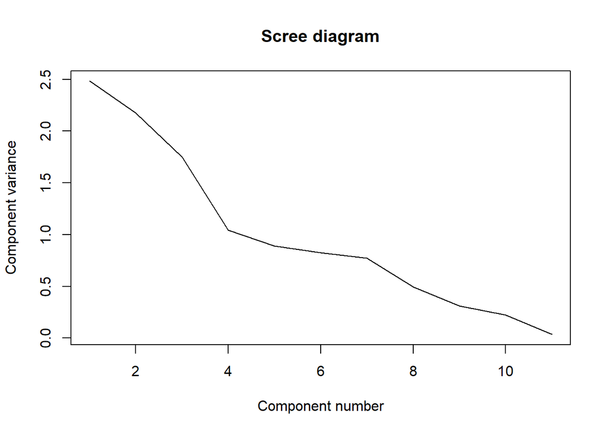

```r
plot(eigen_dataset, xlab = "Component number", ylab = "Component variance", type = "l", main = "Scree diagram")
```

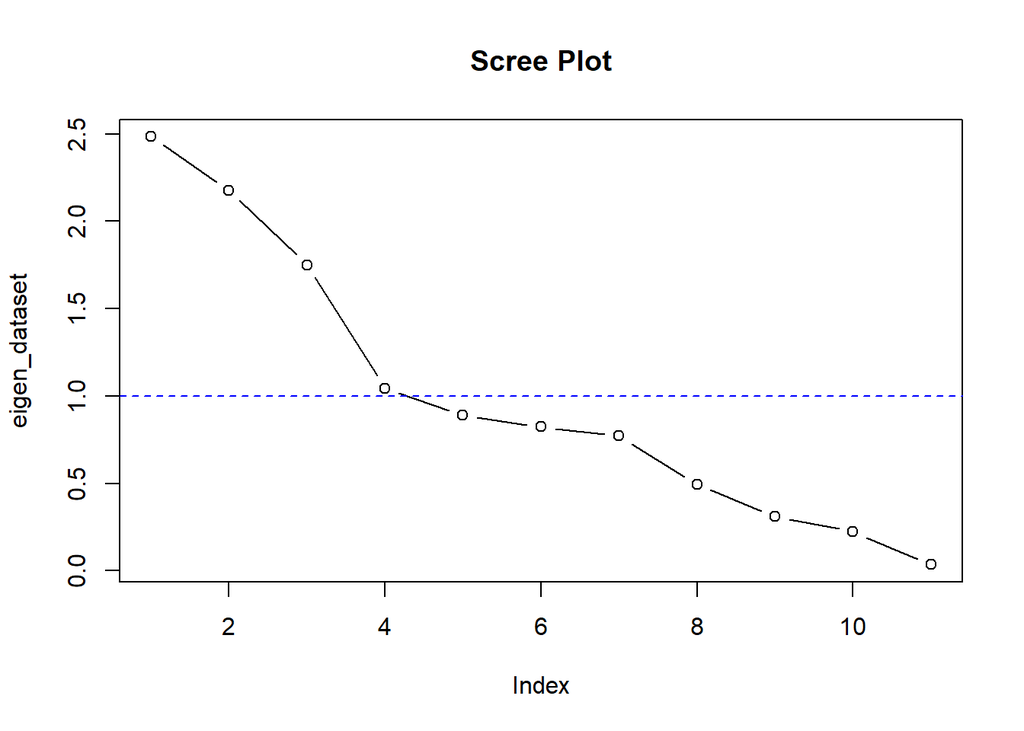

```r
plot(eigen_dataset, type = "b", main="Scree Plot")
abline(h=1,col="blue",lty=2)
```

```r
library(factoextra)
```

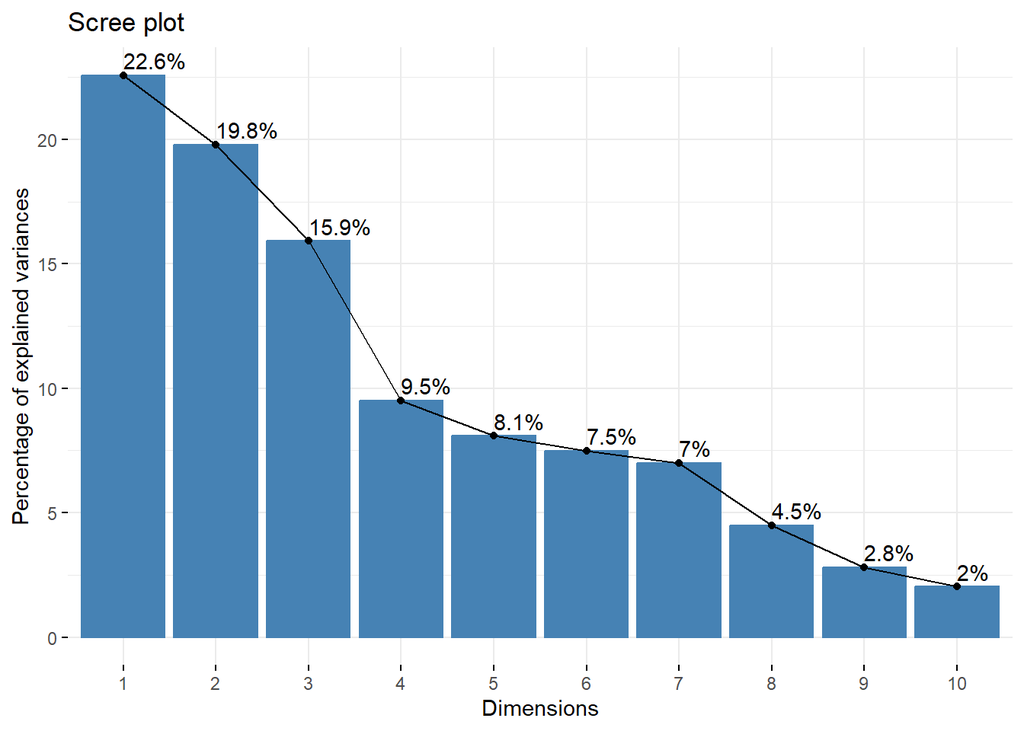

```r
fviz_eig(dataset_pca, addlabels = TRUE)
```

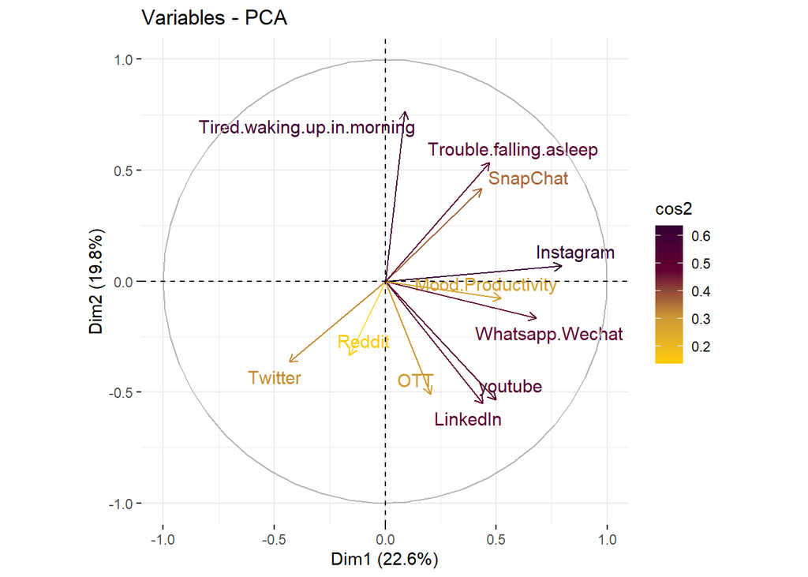

```r
fviz_pca_var(dataset_pca,col.var = "cos2",
             gradient.cols = c("#FFCC00", "#CC9933", "#660033", "#330033"),
             repel = TRUE)
```

Plot shows which variables are correlated. Here, Linkedin, Snapchat, Instagram, Youtube, Whatsapp/Wechat, Mood Productivity.

## Clustering

#1) Hierarchical

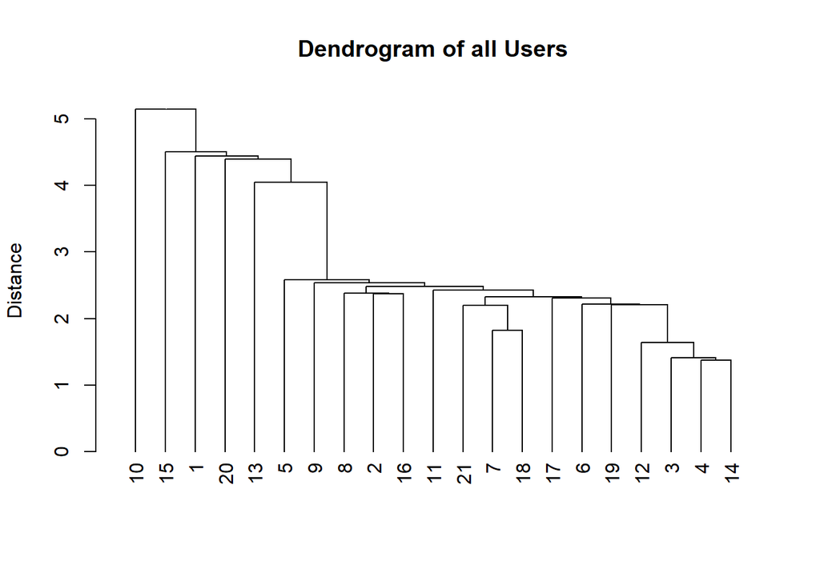

```r
library(cluster)
library(readr)
library(factoextra)
library(magrittr)
library(NbClust)

dist.dataset <- dist(stddataset, method="euclidean")
colnames(dist.dataset) <- rownames(dist.dataset)

clusdataset.nn <- hclust(dist.dataset, method = "single")

options(repr.plot.width=10, repr.plot.height=6)  # Adjust the plot size as needed
plot(as.dendrogram(clusdataset.nn), ylab="Distance",
     main="Dendrogram of all Users")
```

Insight: I think the optimal number of clusters are 5

## Non-hierarchical clustering/ K-means clustering

```r
(kmeans2.dataset <- kmeans(stddataset,4,nstart = 10))
```

```
## K-means clustering with 4 clusters of sizes 10, 8, 1, 2
##
## Cluster means:
##     Instagram   LinkedIn    SnapChat    Twitter Whatsapp.Wechat     youtube
## 1 -0.04316733 -0.4473016  0.06253091  0.0864148      -0.3191873 -0.51124904
## 2  0.38969382  0.7168166  0.04817601 -0.4236336       0.7338259  0.65971707
## 3 -1.63532317 -1.4640746 -0.56966199 -0.4497850      -1.3481161  0.01589432
## 4 -0.52527701  0.1012791 -0.22052762  1.4873530      -0.6653086 -0.09057022
##           OTT     Reddit Mood.Productivity Tired.waking.up.in.morning
## 1 -0.34354656 -0.2343871         0.2182179                  0.7590721
## 2  0.09886135 -0.3292004         0.2182179                 -0.6900656
## 3 -0.66869655 -0.3292004        -4.3643578                 -0.6900656
## 4  1.65663569  2.6533374         0.2182179                 -0.6900656
##   Trouble.falling.asleep
## 1              0.3450328
## 2             -0.1725164
## 3             -0.6900656
## 4             -0.6900656
##
## Clustering vector:
##  [1] 4 2 2 2 1 2 1 1 2 3 1 1 1 1 4 1 2 1 2 2 1
##
## Within cluster sum of squares by cluster:
## [1] 63.72859 47.21265  0.00000 18.90864
##  (between_SS / total_SS =  41.0 %)
##
## Available components:
##
## [1] "cluster"      "centers"      "totss"        "withinss"     "tot.withinss"
## [6] "betweenss"    "size"         "iter"         "ifault"
```

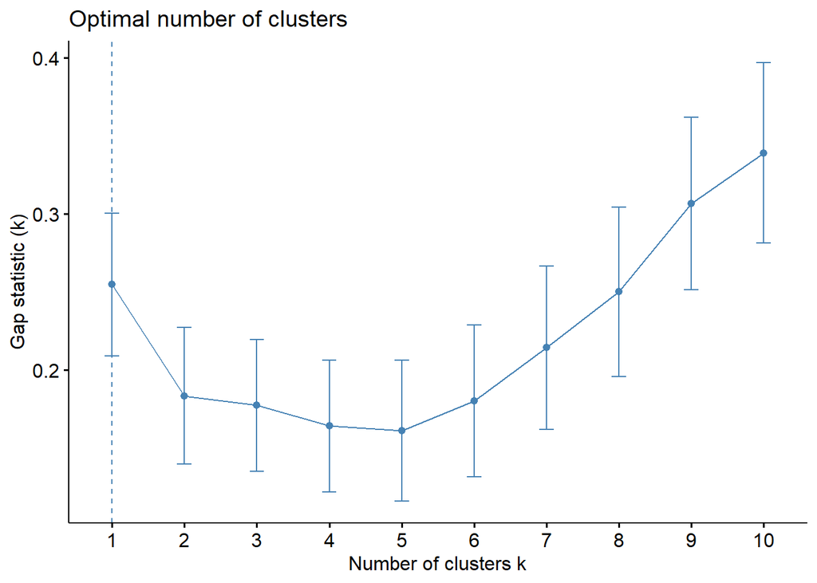

```r
gap_stat <- clusGap(stddataset, FUN = kmeans, nstart = 10, K.max = 10, B = 50)

fviz_gap_stat(gap_stat)
```

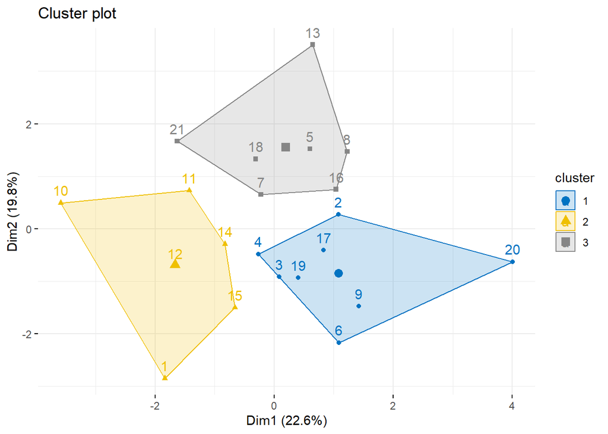

```r
set.seed(123)
## Perform K-means clustering
km.res3 <- kmeans(stddataset, 3, nstart = 25)
# Visualize clusters
fviz_cluster(km.res3, data = stddataset,
             ellipse.type = "convex",
             palette = "jco",
             ggtheme = theme_minimal())
```

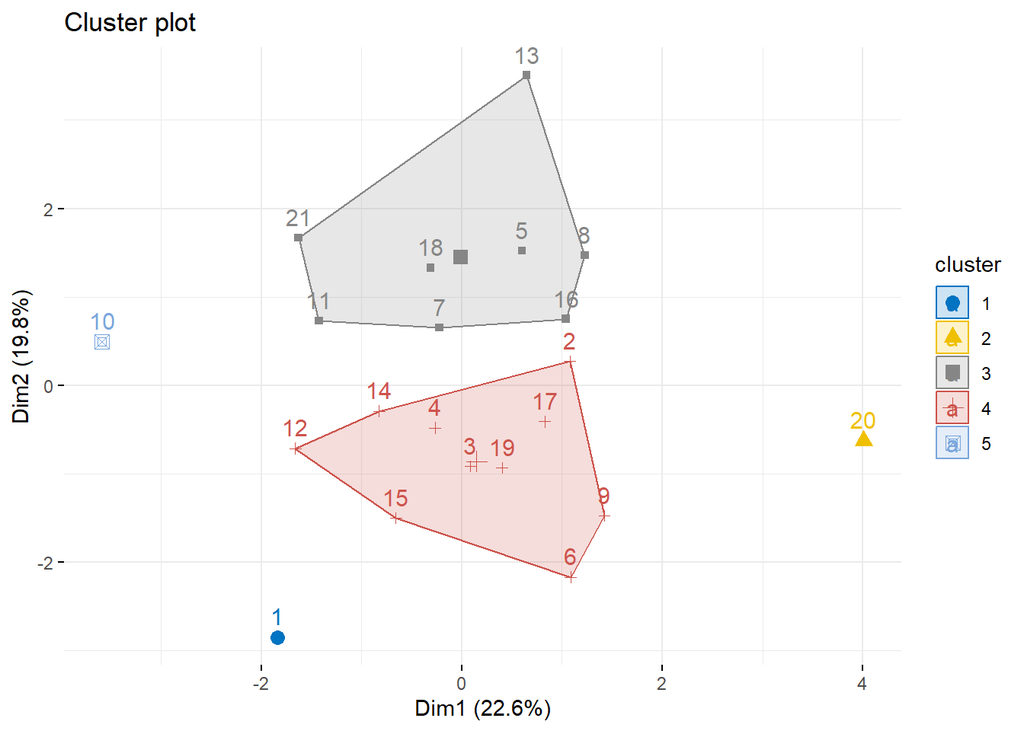

```r
set.seed(123)
## Perform K-means clustering
km.res5 <- kmeans(stddataset, 5, nstart = 25)
# Visualize clusters
fviz_cluster(km.res5, data = stddataset,
             ellipse.type = "convex",
             palette = "jco",
             ggtheme = theme_minimal())
```

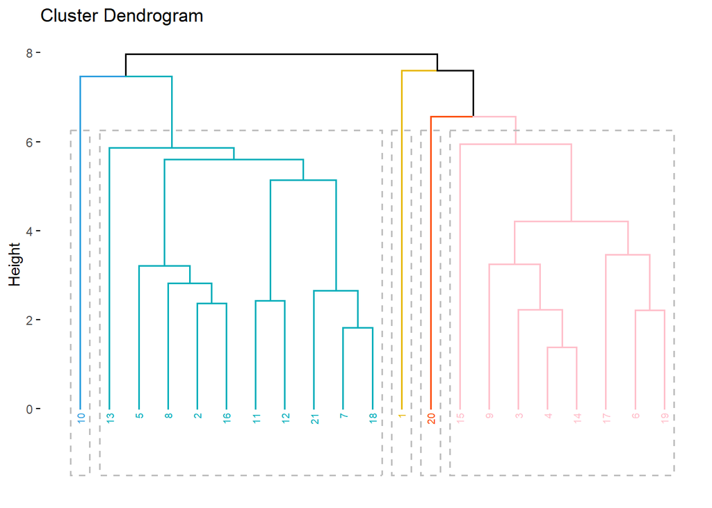

```r
res.hc <- stddataset %>% scale() %>% dist(method = "euclidean") %>%
  hclust(method = "ward.D2")  # Change matstd.dataset to your datasetset

# Visualize the Dendrogram
fviz_dend(res.hc, k = 5,  # Cut in four groups
          cex = 0.5,  # label size
          k_colors = c("#2E9FDF", "#00AFBB", "#E7B800", "#FC4E07", "pink"),
          color_labels_by_k = TRUE,  # color labels by groups
          rect = TRUE)
```

## Factor Analysis

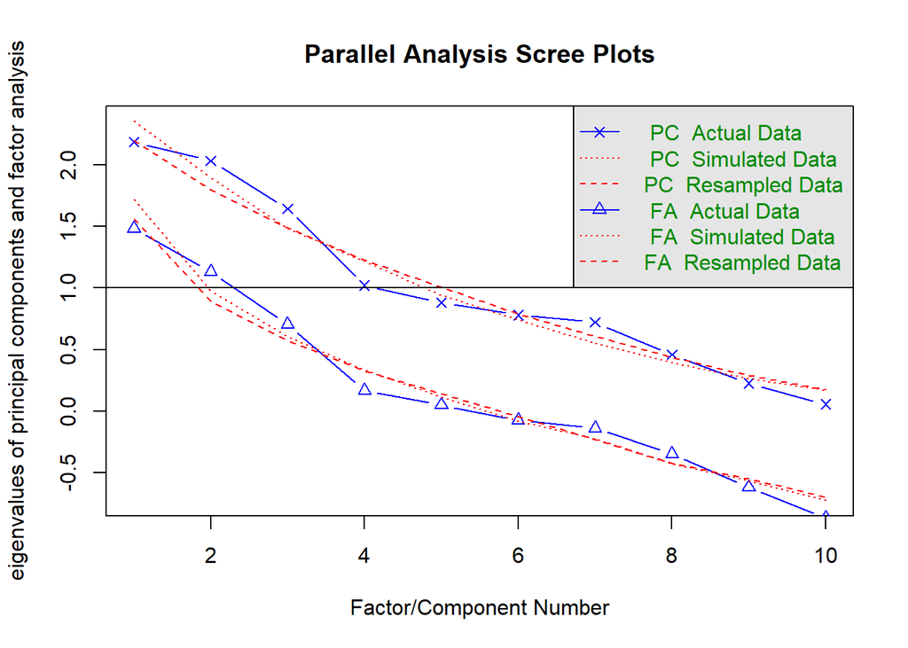

```
## Parallel analysis suggests that the number of factors =  0  and the number of components =  0
```

```r
library(psych)
fa.parallel(dataset[-1])
```

Parallel analysis suggests that the number of factors = 0 and the number of components = 0

```r
fit.pc <- principal(dataset[-1], nfactors=3, rotate="varimax")
fit.pc
```

```
## Principal Components Analysis
## Call: principal(r = dataset[-1], nfactors = 3, rotate = "varimax")
## Standardized loadings (pattern matrix) based upon correlation matrix
##                              RC1   RC2   RC3   h2   u2 com
## LinkedIn                    0.76  0.14 -0.01 0.59 0.41 1.1
## SnapChat                    0.01 -0.04  0.75 0.56 0.44 1.0
## Twitter                    -0.32  0.86 -0.08 0.86 0.14 1.3
## Whatsapp.Wechat             0.72 -0.30  0.16 0.63 0.37 1.4
## youtube                     0.75 -0.01 -0.19 0.59 0.41 1.1
## OTT                         0.25  0.79  0.19 0.72 0.28 1.3
## Reddit                     -0.01  0.47 -0.12 0.23 0.77 1.1
## Mood.Productivity           0.37  0.23  0.53 0.47 0.53 2.2
## Tired.waking.up.in.morning -0.39 -0.40  0.55 0.61 0.39 2.7
## Trouble.falling.asleep     -0.11 -0.09  0.75 0.58 0.42 1.1
##
##                        RC1  RC2  RC3
## SS loadings           2.12 1.92 1.82
## Proportion Var        0.21 0.19 0.18
## Cumulative Var        0.21 0.40 0.59
## Proportion Explained  0.36 0.33 0.31
## Cumulative Proportion 0.36 0.69 1.00
##
## Mean item complexity =  1.4
## Test of the hypothesis that 3 components are sufficient.
##
## The root mean square of the residuals (RMSR) is  0.12
##  with the empirical chi square  26.45  with prob <  0.09
##
## Fit based upon off diagonal values = 0.74
```

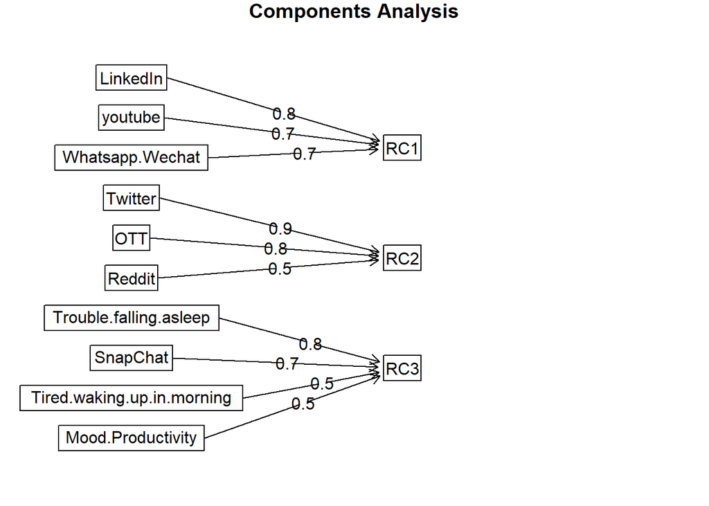

```r
fa.diagram(fit.pc)
```

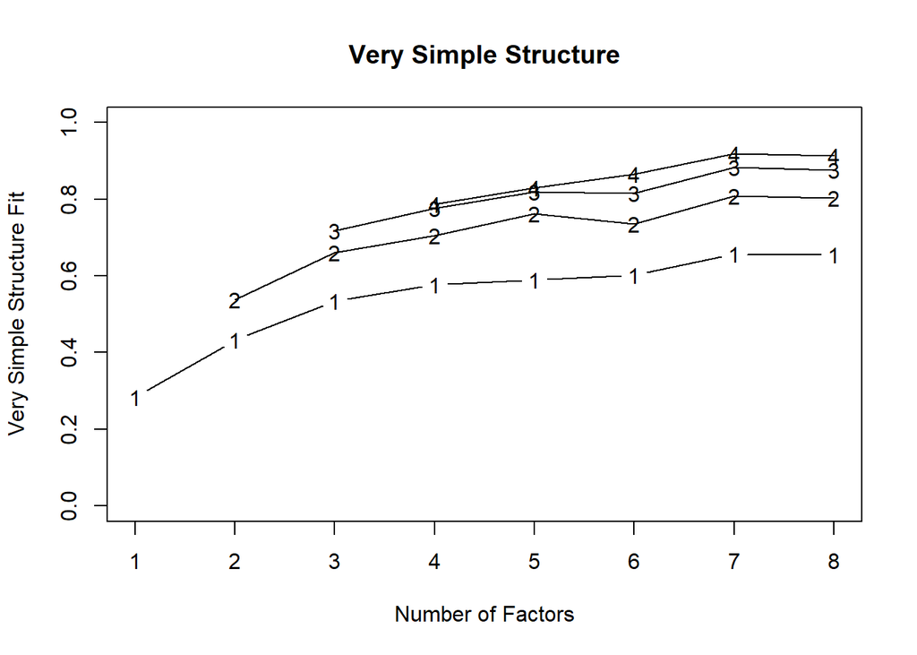

```
##
## Very Simple Structure
## Call: vss(x = dataset[-1])
## VSS complexity 1 achieves a maximimum of 0.66  with  7  factors
## VSS complexity 2 achieves a maximimum of 0.81  with  7  factors
##
## The Velicer MAP achieves a minimum of 0.07  with  1  factors
## BIC achieves a minimum of  -57.79  with  1  factors
## Sample Size adjusted BIC achieves a minimum of  10.11  with  5  factors
##
## Statistics by number of factors
##   vss1 vss2   map dof   chisq  prob sqresid  fit RMSEA   BIC SABIC complex
## 1 0.28 0.00 0.066  35 4.9e+01 0.061   10.61 0.28 0.128 -57.8    50     1.0
## 2 0.43 0.54 0.080  26 3.3e+01 0.159    6.84 0.54 0.103 -46.1    34     1.2
## 3 0.53 0.66 0.091  18 2.2e+01 0.213    4.18 0.72 0.097 -32.3    23     1.5
## 4 0.58 0.70 0.131  11 1.7e+01 0.098    3.14 0.79 0.158 -16.1    18     1.6
## 5 0.59 0.76 0.191   5 9.9e+00 0.078    2.42 0.84 0.210  -5.3    10     1.6
## 6 0.60 0.74 0.233   0 5.7e+00    NA    1.77 0.88    NA    NA    NA     1.7
## 7 0.66 0.81 0.332  -4 3.3e+00    NA    0.77 0.95    NA    NA    NA     1.6
## 8 0.65 0.80 0.531  -7 2.4e-08    NA    0.53 0.96    NA    NA    NA     1.5
##    eChisq    SRMR eCRMS eBIC
## 1 6.5e+01 1.9e-01  0.21  -42
## 2 3.0e+01 1.3e-01  0.17  -49
## 3 1.1e+01 7.6e-02  0.12  -44
## 4 6.0e+00 5.6e-02  0.11  -27
## 5 2.7e+00 3.8e-02  0.11  -12
## 6 1.1e+00 2.4e-02    NA   NA
## 7 3.5e-01 1.4e-02    NA   NA
## 8 5.4e-10 5.3e-07    NA   NA
```

```r
vss(dataset[-1])
```